# Penske - Sentiment Analysis

Analyst - Narcel Reedus

Date - November 2, 2017

# *Summary*

## The objective of this project is to generate a sentiment analysis using a corpus of four negative online reviews of Penske Truck Rental. The analysis will assist in revealing and isolating any apparent systemic lapse in service standards within the process of leasing Penske trucks. I copied and pasted four online reviews from the website [Ripoff Report](http://www.ripoffreport.com/reports/search/advanced?cat_id=237&title=%22Penske%22&e_city=&e_state=&e_country=USA) and created separate .txt documents for each review.

## The analysis uses the [Minqing Hu and Bing Liu](http://www.cs.uic.edu/~liub/FBS/sentiment-analysis.html) Positive and Negative Opinion Lexicons from their paper: Minqing Hu and Bing Liu. “Mining and Summarizing Customer Reviews.” Proceedings of the ACM SIGKDD International Conference on Knowledge Discovery and Data Mining (KDD-2004), Aug 22-25, 2004, Seattle, Washington, USA,

## The analysis also generates postive and negative sentiment scores for each document. The documents originate from a complaint website, therefore, high negative scores are natually expected. The key take away here is the ability to identify the frequency of outlier negative sentiments that may appear across the corpus.

# *Process*

### Load packages

```r
library(tm)
library(wordcloud)
library(stringr)
library(kableExtra)
library(httr)
```

### Assign corpus of Penske reviews to a folder in the working direcory

```r
folder <- "C:/Users/narce/OneDrive/Documents/GitHub/Penske/Penske/corpus"
```

### Confirm the contents of the folder

```r
list.files(path=folder, pattern="*.txt")
```

```
## [1] "Penske_1.txt" "Penske_2.txt" "Penske_3.txt" "Penske_4.txt"
```

### Create character vector of the four file names

```r
filelist <- list.files(path=folder, pattern="*.txt")
filelist
```

```
## [1] "Penske_1.txt" "Penske_2.txt" "Penske_3.txt" "Penske_4.txt"
```

```r
str(filelist)
```

```
##  chr [1:4] "Penske_1.txt" "Penske_2.txt" "Penske_3.txt" "Penske_4.txt"
```

### Create a separate file path for each element and saves that into a new value, filelist

```r
filelist <-paste(folder, "\\", filelist, sep="")
```

```r
filelist
```

```
## [1] "C:/Users/narce/OneDrive/Documents/GitHub/Penske/Penske/corpus\\Penske_1.txt"
## [2] "C:/Users/narce/OneDrive/Documents/GitHub/Penske/Penske/corpus\\Penske_2.txt"
## [3] "C:/Users/narce/OneDrive/Documents/GitHub/Penske/Penske/corpus\\Penske_3.txt"
## [4] "C:/Users/narce/OneDrive/Documents/GitHub/Penske/Penske/corpus\\Penske_4.txt"
```

### Import each file as a character vector using laaply and the read.Lines function. ReadLines will treat each line of text as a separate element in a character vector. Laaply applies this to each file in the folder.

```r
library(knitr)
kable(lapply(filelist, FUN=readLines), "html", caption = "Online Reviews") %>%
  kable_styling() %>%
  scroll_box(width = "915px", height = "200px")
```

Online Reviews

| ï»¿Blood all over the inside of one of the two trucks I rented! I reserved two trucks one of the reservations got lost but they were able to get a truck from another location. When I picked up the sec… |
| --- |
| ….. I told the manager that he needed to come out and look at the back of this truck and he did. He had a loss for words but ended up talking some pictures. We went back in side and he asked me when t… |

| ï»¿I had made a Penske truck rental reservation for August 31st at Home Depot so that I could help my daughter move from one apartment to another. Since first making the reservation in early August, I… |
| --- |
| When my wife and I arrived at the appointed time, we were informed by Home Depot employees that there was no rental truck available, nor would there be. We were further informed that we were not the f… |
| After hanging up, the Home Depot employee informed us that Penske had not only over-booked a significant number of rental reservations for that day, but that they had done so intentionally–saying that… |
| The result to me and my family was not pleasant, and had far reaching effects on friends and family for the entire rain-soaked Labor Day weekend. What I can say right now is that even though the weeke… |
| The effects have also, unfortunately, spilled over to my relationship with Home Depot. In the 60 minutes prior to my scheduled pick up my truck rental on the 31st, my wife and I purchased two rooms of… |
| You may ask, why am I angry with Home Depot? After all, they weren’t the ones who let me and my family in the lurch. The answer is a simple business fact: you are known by the company you keep and the… |

| ï»¿My wife and I were recently married, and decided to move across the country from Sonoma CA to Redwood NY to be closer to her parents. We really had no issues until hitting the 80/90 East leaving Ch… |
| --- |
| We pulled over to inspect the damage and found that the plexiglass had actually hit corner first into the bumper. She was lucky to be alive. We drove straight through the night and arrived in NY at ab… |

| ï»¿My husband and I rented a 15 ft truck from Penske in Bakersfield, CA. On 11/2/03 at 4:15 am while 1 mile up the grapevine on interstate 5 the truck came to an abrupt stop while we were in the middl… |
| --- |
| Meanwhile large trucks were passing on our right, cars on the left, trying to avoid hitting us. We got to the shoulder of the road; my husband called 911 and alerted the CHP and asked to have a tow tr… |
| We stood out in 30 degree freezing temperatures and waved by oncoming traffice to avoid hitting the truck. Twenty minutes later the CHP officer showed up. He parked his car behind our rental truck and… |
| Thirty minutes after the CHP officer arrived the tow truck came. We were so relieved to get the rental truck off the road and onto the shoulder. After standing out in the cold for 1 1/4 hours (We were… |
| When we arrived were were told that “we are not responsible for the contents of the truck”. Needless to say at this point Penske has done nothing for us except demand that we pick up the truck’s conte… |
| The manager told me they opened the back of the truck so I have no idea if everything is still there. My husband and I were nearly killed. We sat in a vehicle for two minutes or so (as we sat there I … |
| We feel that we were put into an unsafe vehicle. We were lucky that we walked away. Others in the same situation may not be as lucky. The bearing in the differential went out. This is what caused our … |
| Evelyn |
| Bakersfield, California |
| U.S.A. |

### Assign a new vector to filelistA

```r
filelistA <- lapply(filelist, FUN=readLines)
```

```r
lapply(filelistA, FUN = paste, collapse=" ")
```

```r
corpus <-lapply(filelistA, FUN = paste, collapse=" ")
```

# *Munging the Data*

### Removes punctuations

```r
corpus2 <- gsub(pattern = "\\W", replace=" ", corpus)
```

### Removes numbers

```r
corpus2 <- gsub(pattern = "\\d", replacement = " ", corpus2)
```

### Makes text lowercase

```r
corpus2<-tolower(corpus2)
```

### Removes stopwords (and, the, a…)

```r
corpus2 <- removeWords(corpus2, stopwords("english"))
```

```r
corpus2 < gsub(pattern = "\\b[A-z]\\b{1}", replace=" ", corpus2)
```

```
## [1] FALSE FALSE FALSE FALSE
```

### Removes white space

```r
corpus2 <- stripWhitespace(corpus2)
```

### Creates a wordcloud visualization of the most used words in the corpus

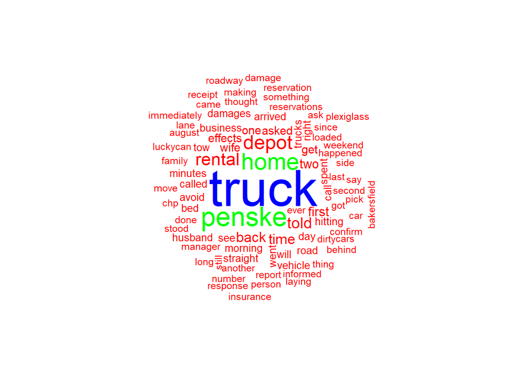

```r
wordcloud(corpus2, random.order = FALSE, colors = rainbow(3))
```

### Creates a corpus

```r
corpus3 <- Corpus(VectorSource(corpus2))
```

```r
summary(corpus3)
```

```
##   Length Class             Mode
## 1 2      PlainTextDocument list
## 2 2      PlainTextDocument list
## 3 2      PlainTextDocument list
## 4 2      PlainTextDocument list
```

### Creates a Term document matrix

```r
tdm <- TermDocumentMatrix(corpus3)
```

### Creates the matrix

```r
as.matrix(tdm)
viewmatrix <- as.matrix(tdm)
```

### Changes the names of the columns (Read1 = Reading, PA, Malb = Malborough, MA, Read2 - Reading, PA, Baker = Bakersfield, CA)

```r
colnames(viewmatrix) <- c("Read1", "Malb", "Read2", "Baker")
```

```r
  kable(as.matrix(tdm), "html") %>%
  kable_styling() %>%
  scroll_box(width = "915px", height = "200px")
```

|  | 1 | 2 | 3 | 4 |
| --- | --- | --- | --- | --- |
| able | 1 | 0 | 1 | 0 |
| almost | 1 | 0 | 0 | 0 |
| also | 1 | 1 | 0 | 0 |
| another | 2 | 1 | 0 | 0 |
| asked | 1 | 1 | 1 | 2 |
| asking | 1 | 0 | 0 | 0 |
| atleast | 1 | 0 | 0 | 0 |
| back | 3 | 0 | 2 | 2 |
| believe | 1 | 0 | 0 | 0 |
| biohazard | 1 | 0 | 0 | 0 |
| blood | 2 | 0 | 0 | 0 |
| call | 1 | 1 | 2 | 0 |
| called | 1 | 1 | 1 | 1 |
| care | 1 | 0 | 0 | 0 |
| cargo | 1 | 0 | 0 | 0 |
| claimed | 1 | 0 | 0 | 0 |
| clean | 1 | 0 | 0 | 0 |
| come | 1 | 0 | 0 | 0 |
| coming | 1 | 0 | 0 | 0 |
| compared | 1 | 0 | 0 | 0 |
| completely | 1 | 0 | 0 | 0 |
| conclusions | 1 | 0 | 0 | 0 |
| condition | 1 | 0 | 0 | 0 |
| contracted | 1 | 0 | 0 | 0 |
| copy | 1 | 0 | 0 | 0 |
| corporate | 1 | 0 | 0 | 0 |
| crime | 1 | 0 | 0 | 0 |
| dark | 1 | 0 | 0 | 0 |
| date | 2 | 0 | 0 | 0 |
| didn | 1 | 0 | 0 | 0 |

[output cut: 506 more lines]

```r
viewmatrix <- as.matrix(tdm)
```

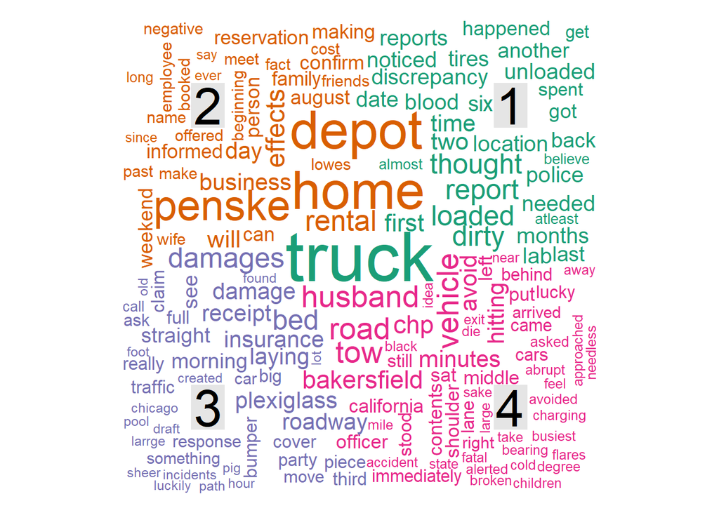

```r
comparison.cloud(viewmatrix)
```

```r
opinion.lexicon.pos <- scan("positive-words.txt", what="character", comment.char = ";")

opinion.lexicon.neg <- scan("negative-words.txt", what="character", comment.char = ";")
```

# *Bag of Words*

### Creates a bag of words for each document in the corpus.

```r
kable(corpus4 <- str_split(corpus2, pattern="\\s+"), "html", caption = "**Bag of Words**") %>%
  kable_styling() %>%
  scroll_box(width = "915px", height = "200px")
```

**Bag of Words**

| ï |
| --- |
| blood |
| inside |
| one |
| two |
| trucks |
| rented |
| reserved |
| two |
| trucks |
| one |
| reservations |
| got |
| lost |
| able |
| get |
| truck |
| another |
| location |
| picked |
| second |
| truck |
| noticed |
| dirty |
| time |
| thought |
| someone |
| hauling |
| tires |
| wasn |
| t |

[output cut: 144 more lines]

| ï |
| --- |
| made |
| penske |
| truck |
| rental |
| reservation |
| august |
| st |
| home |
| depot |
| help |
| daughter |
| move |
| one |
| apartment |
| another |
| since |
| first |
| making |
| reservation |
| early |
| august |
| received |
| two |
| calls |
| penske |
| one |
| shortly |
| making |
| reservation |
| confirm |

[output cut: 291 more lines]

| ï |
| --- |
| wife |
| recently |
| married |
| decided |
| move |
| across |
| country |
| sonoma |
| ca |
| redwood |
| ny |
| closer |
| parents |
| really |
| issues |
| hitting |
| east |
| leaving |
| chicago |
| heading |
| early |
| morning |
| rush |
| hour |
| traffic |
| spotted |
| something |
| shining |
| roadway |
| cars |

[output cut: 210 more lines]

| ï |
| --- |
| husband |
| rented |
| ft |
| truck |
| penske |
| bakersfield |
| ca |
| mile |
| grapevine |
| interstate |
| truck |
| came |
| abrupt |
| stop |
| middle |
| lane |
| husband |
| hurried |
| put |
| emergency |
| flashers |
| exit |
| vehicle |
| meanwhile |
| large |
| trucks |
| passing |
| right |
| cars |
| left |

[output cut: 191 more lines]

### Matches the bag of words to the positive lexicon of words. Doc1 = 3, Doc2 = 10, Doc3 = 5, Doc4 = 4.

```r
lapply(corpus4, function(x) { sum(!is.na(match(x, opinion.lexicon.pos)))})
```

```
## [[1]]
## [1] 3
##
## [[2]]
## [1] 10
##
## [[3]]
## [1] 5
##
## [[4]]
## [1] 4
```

### Matches the bag of words to the negative lexicon of words. Doc1 = 10, Doc2 = 7, Doc3 = 12, Doc4 = 14

```r
lapply(corpus4, function(x) { sum(!is.na(match(x, opinion.lexicon.neg)))})
```

```
## [[1]]
## [1] 10
##
## [[2]]
## [1] 7
##
## [[3]]
## [1] 12
##
## [[4]]
## [1] 14
```

### Calculates the sum totals of Positive sentiments vs negative sentiments in the corpus. Doc1 = -7, Doc2 = 3, Doc3 = -7, Doc4 = -10.

```r
lapply(corpus4, function(x) { sum(!is.na(match(x, opinion.lexicon.pos))) - sum(!is.na(match(x, opinion.lexicon.neg)))})
```

```
## [[1]]
## [1] -7
##
## [[2]]
## [1] 3
##
## [[3]]
## [1] -7
##
## [[4]]
## [1] -10
```

# *Sentiment Scores*

```r
scores <-unlist(lapply(corpus4, function(x) { sum(!is.na(match(x, opinion.lexicon.pos))) - sum(!is.na(match(x, opinion.lexicon.neg)))}))
```